# Exercise 1 - Seurat

Rockefeller University, Bioinformatics Resource Centre

https://rockefelleruniversity.github.io/scRNA-seq

These exercises are about manipulate single-cell data with Seurat. Please download the counting matrix from [DropBox](https://www.dropbox.com/sh/ztu0pucvu21szxm/AABGUhTryKp1T1CsoEUFRPcwa?dl=0) and loading them into a Seurat object. Or you may also used the rds file *data/scSeq_CKO_1kCell_ori.rds*.

## **Exercise 1** - **Data manipulation with Seurat**

### Loading data

1. Create a Seurat object by reading the count data from BOX or by loading the rds file. Then calculate mitochondrial contents of each ell

```
##                        orig.ident nCount_RNA nFeature_RNA dset percent.mt
## CKO_AGACGTTCAGCTGGCT-1        CKO       2679         1200  CKO  0.1119821
## CKO_TTAACTCGTAGTACCT-1        CKO        813          476  CKO 14.3911439
## CKO_GAGGTGAGTCTAGTGT-1        CKO       4852         1759  CKO 10.9233306
## CKO_CTCGTACAGCTAAGAT-1        CKO       1750          672  CKO 46.0000000
## CKO_AGGGAGTTCAAACCAC-1        CKO       4632         1585  CKO  5.3108808
## CKO_ATTATCCTCAACGGCC-1        CKO       2498         1177  CKO  3.8030424
```

### Basic QC

2. Access the read counts (nCount_RNA), gene counts (nFeature_RNA), and mitochondrial content (percent.mt) for each cell and draw a violin plot of each.

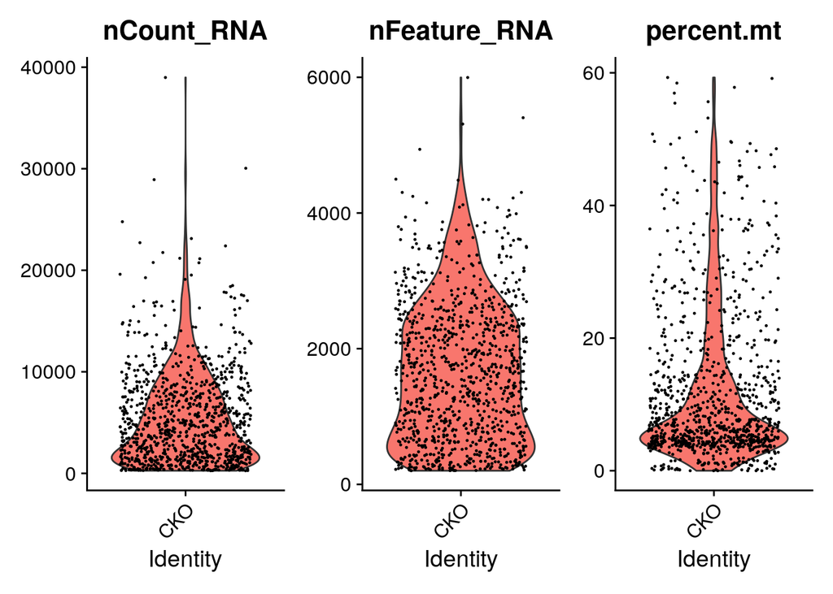

3. Mmake a dot plot for nCount_RNA vs nFeature_RNA. *NOTE: At this step try to keep an eye out potential doublets.*

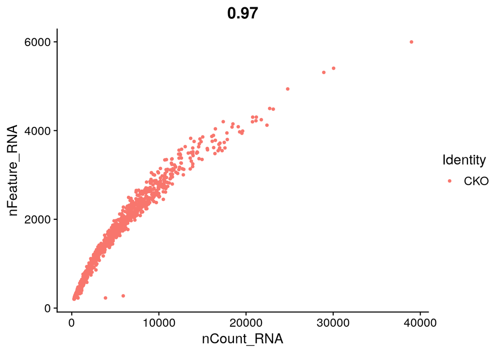

4. Make a dot plot for nCount_RNA vs percent.mt. *NOTE: At this step try to keep an eye out potential cell debris.*

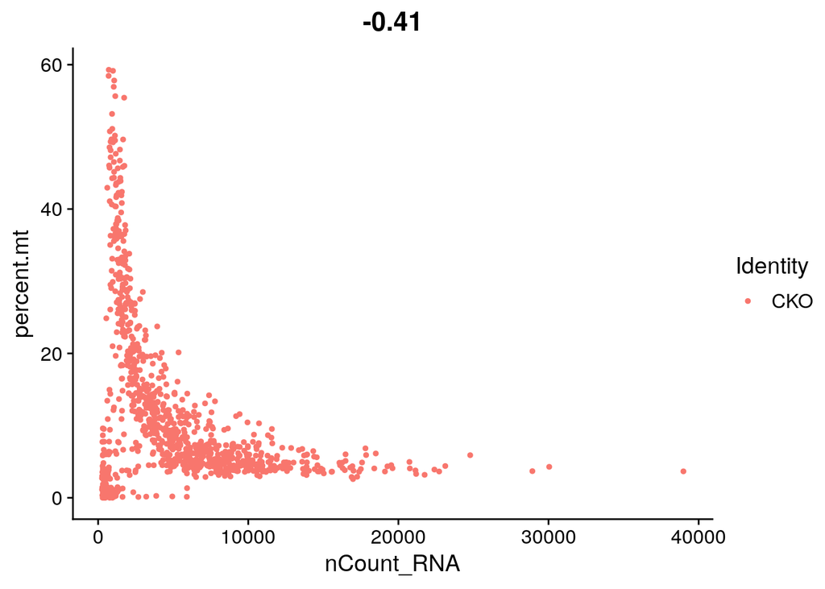

5. Remove cells with percent.mt >= 10 for following analysis

```
## An object of class Seurat
## 14353 features across 619 samples within 1 assay
## Active assay: RNA (14353 features, 0 variable features)
```

### Cell cycle

6. Please estimate cell cycle phase of each cell and make a table to describe how many cells per phase.

```
##
##  G1 G2M   S
## 244 126 249
```

### Normalization and clustering

7. Please scale data regressing to mitochondrial content (percent.mt) and cell cycle (S.score, G2M.score, Phase).
8. Please make principle component analysis (PCA), estimate how many PCs would best represent this data, then make clustering and UMAP plot.
- check for up to 30 PCs.
- elbow plot can be used to determine PCs.

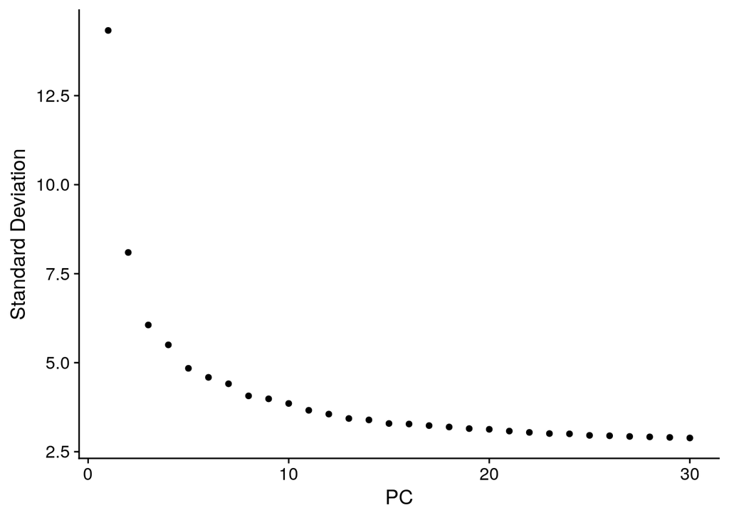

```
## Modularity Optimizer version 1.3.0 by Ludo Waltman and Nees Jan van Eck
##
## Number of nodes: 619
## Number of edges: 17852
##
## Running Louvain algorithm...
## Maximum modularity in 10 random starts: 0.8179
## Number of communities: 7
## Elapsed time: 0 seconds
```

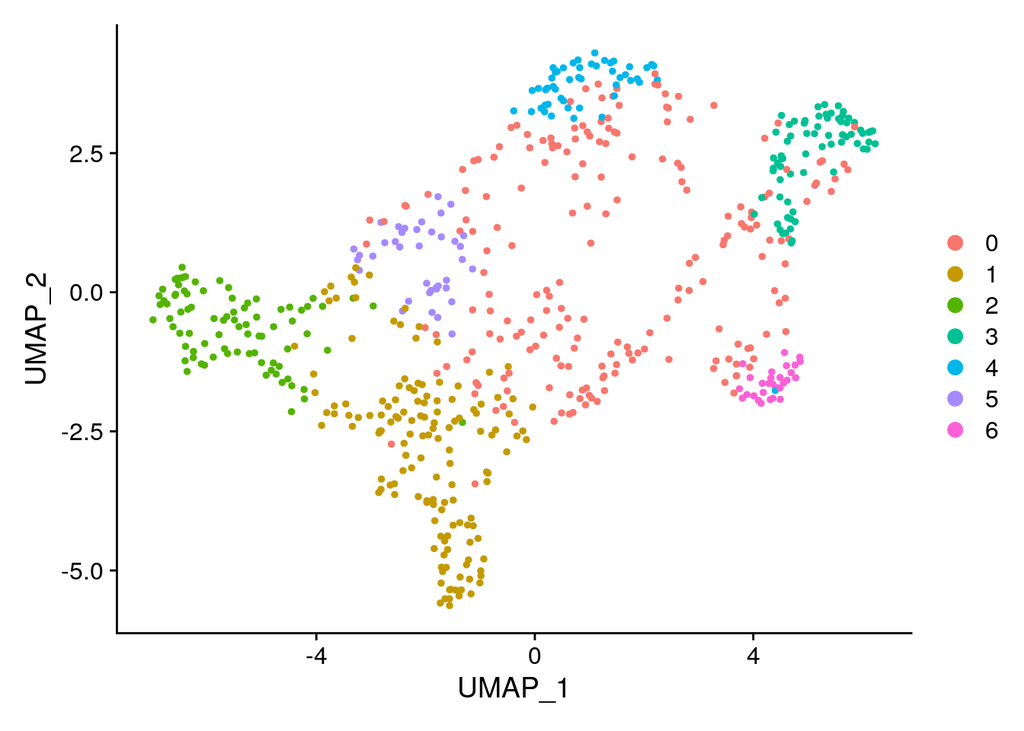

### Marker genes

```
##                      p_val avg_log2FC pct.1 pct.2    p_val_adj cluster
## Dcn           2.817301e-12  3.9094752 0.788 0.483 4.043672e-08       0
## Cxcl14        1.519849e-07 15.4620537 0.951 0.755 2.181439e-03       0
## Kremen2       4.066752e-07  0.3319331 0.670 0.416 5.837009e-03       0
## Slc1a3        1.092146e-06  3.4909041 0.389 0.202 1.567557e-02       0
## Dlk2          3.853981e-06  0.5031396 0.251 0.108 5.531620e-02       0
## 4631405K08Rik 7.839675e-05  0.6911469 0.355 0.216 1.000000e+00       0
##                        gene
## Dcn                     Dcn
## Cxcl14               Cxcl14
## Kremen2             Kremen2
## Slc1a3               Slc1a3
## Dlk2                   Dlk2
## 4631405K08Rik 4631405K08Rik
```

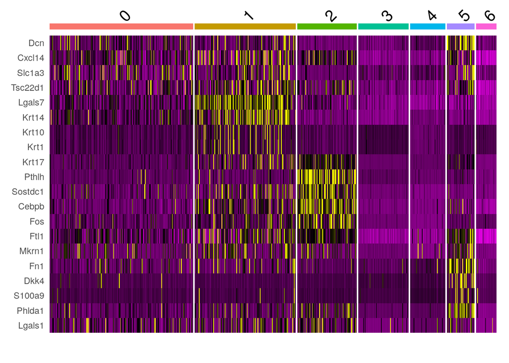

### Advanced plots

10. Please display the top marker gene of each cluster in FeaturePlot and RidgePlot

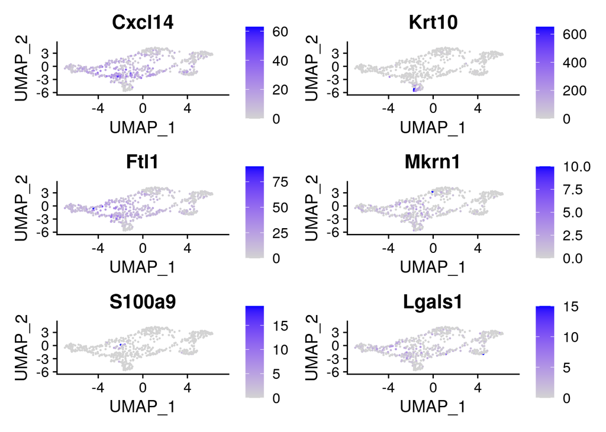

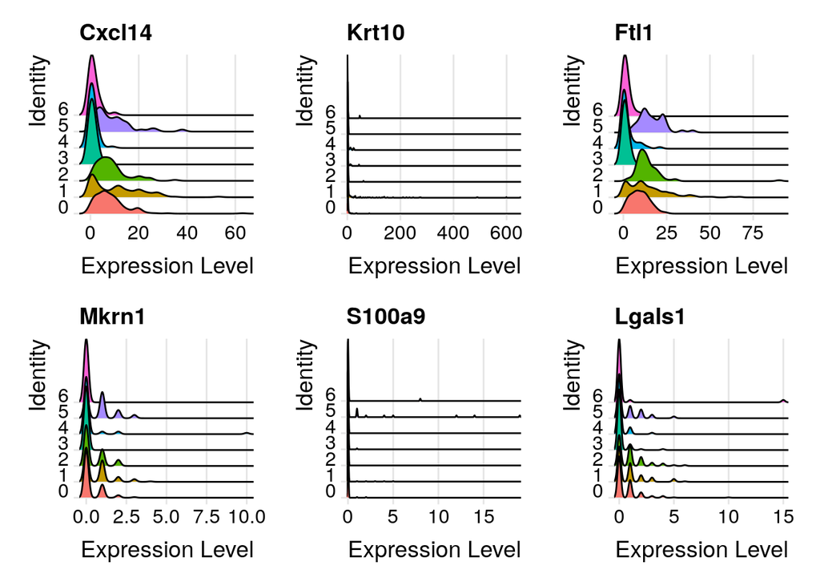